# Data Analytics with SAX

###### Below are several use cases of Java garbage collection (GC). Each case identifies a behavioral pattern over a period of time. The raw data in the use cases is simple time-series data with time on the x-axis and memory utilization on the y-axis. Each use case will be converted into its corresponding symbolic format (SAX) and used as a pattern for machine learning and use by a decision tree. The goal here being the ability to identify patterns over time and evaluate whether or not it is problematic.

## Case 1 - Normal GC

###### This use case is a typical oscillating GC pattern where the memory climbs and is then periodically reclaimed. This behavior would be expected and should not result in error identification.

```
'abcdefghbcdefghcdefghdefghefghghhhbcdefghabcdefghbcdefghcdef…'
```

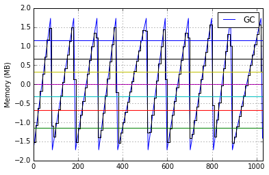

```python
import pandas as pd
import numpy as np
from scipy.stats import norm
import matplotlib.pyplot as plt
from IPython.display import display

window_size = 10
alphabet = ['a','b','c','d','e','f','g','h']
alphabet_size = len(alphabet)

# SAX Boundaries

boundaries = norm.ppf(np.linspace(1./alphabet_size,
                                  1-1./alphabet_size,
                                  alphabet_size-1))

sax_dict = dict(zip(boundaries, alphabet))

case1 = pd.read_csv('PycharmProjects/saxanalytics/case1.csv',
                    sep=',',
                    parse_dates=[0],
                    header=None,
                    names=['Time','GC'])

# z-norm the data
case1 = ((case1 - case1.mean())/case1.std())

# discretize the data using piecewise aggregate approximation (PAA)
paa = np.array_split(case1['GC'], (len(case1['GC']) / window_size) + 1)
paa = np.asarray(map(lambda xs: xs.mean(), paa))
paa_size = len(paa) - 1

ax = case1.plot()
ax.set_ylabel('Memory (MB)')

x1 = 0
x2 =  window_size

for i in xrange(0, paa_size):
    ax.plot([x1, x2], [paa[i], paa[i]], '-k')
    ax.plot([x2, x2], [paa[i], paa[i+1]], '-k')
    x1 = x1 + window_size
    x2 = x2 + window_size

for line in boundaries:
    ax.plot([0,len(case1)],[line,line])

sax_data = list()

# Convert to SAX representation
for value in paa:
    for key in sort(sax_dict.keys()):
        if value < key:
            sax_data.append(sax_dict[key])
    sax_data.append(alphabet[len(alphabet) - 1])

display(''.join(sax_data))
```

## Case 2 - Single Spike

###### This use case represents a single, abnormal spike in memory usage. While the memory was eventually reclaimed a spike such as this could result in problematic behavior within an application. This is a pattern we would hope to identify using the prescribed approach.

```
'bcdefghbcdefghcdefghdefghefghefghfghghbcdefghbcdefghbcdefghc…'
```

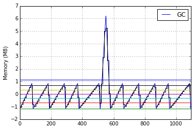

```python
import pandas as pd
import numpy as np
from scipy.stats import norm
import matplotlib.pyplot as plt
from IPython.display import display

window_size = 10
alphabet = ['a','b','c','d','e','f','g','h']
alphabet_size = len(alphabet)

# SAX Boundaries
boundaries = norm.ppf(np.linspace(1./alphabet_size,
                                  1-1./alphabet_size,
                                  alphabet_size-1))

sax_dict = dict(zip(boundaries, alphabet))

case2 = pd.read_csv('PycharmProjects/saxanalytics/case2.csv',
                    sep=',',
                    parse_dates=[0],
                    header=None,
                    names=['Time','GC'])

# z-norm the data
case2 = ((case2 - case2.mean())/case2.std())

paa = np.array_split(case2['GC'], (len(case2['GC']) / window_size) + 1)
paa = np.asarray(map(lambda xs: xs.mean(), paa))
paa_size = len(paa) - 1

ax = case2.plot()
ax.set_ylabel('Memory (MB)')

x1 = 0
x2 =  window_size

for i in xrange(0, paa_size):
    ax.plot([x1, x2], [paa[i], paa[i]], '-k')
    ax.plot([x2, x2], [paa[i], paa[i+1]], '-k')
    x1 = x1 + window_size
    x2 = x2 + window_size

for line in boundaries:
    ax.plot([0,len(case2)],[line,line])

sax_data = list()

# Convert to SAX representation
for value in paa:
    for key in sort(sax_dict.keys()):
        if value < key:
            sax_data.append(sax_dict[key])
    sax_data.append(alphabet[len(alphabet) - 1])

display(''.join(sax_data))
```

## Case 3 - Increasing GC Frequency

###### This use case identifies when GC occurrs with increased frequency. This would occur when a system is stressed or when there is an extreme amount of temporary object creation.

```
'abcdefghabcdefghbcdefghcdefghdefghefghfghghhhbcdefghabcdefgh…'
```

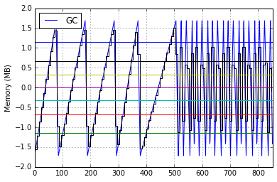

```python
import pandas as pd
import numpy as np
from scipy.stats import norm
import matplotlib.pyplot as plt
from IPython.display import display

window_size = 8
alphabet = ['a','b','c','d','e','f','g','h']
alphabet_size = len(alphabet)


# SAX Boundaries
boundaries = norm.ppf(np.linspace(1./alphabet_size,
                                  1-1./alphabet_size,
                                  alphabet_size-1))

sax_dict = dict(zip(boundaries, alphabet))

case3 = pd.read_csv('PycharmProjects/saxanalytics/case3.csv',
                    sep=',',
                    parse_dates=[0],
                    header=None,
                    names=['Time','GC'])

# z-norm the data
case3 = ((case3 - case3.mean())/case3.std())

paa = np.array_split(case3['GC'], (len(case3['GC']) / window_size) + 1)
paa = np.asarray(map(lambda xs: xs.mean(), paa))
paa_size = len(paa) - 1

ax = case3.plot()
ax.set_ylabel('Memory (MB)')

x1 = 0
x2 =  window_size

for i in xrange(0, paa_size):
    ax.plot([x1, x2], [paa[i], paa[i]], '-k')
    ax.plot([x2, x2], [paa[i], paa[i+1]], '-k')
    x1 = x1 + window_size
    x2 = x2 + window_size

for line in boundaries:
    ax.plot([0,len(case3)],[line,line])

sax_data = list()

# Convert to SAX representation
for value in paa:
    for key in sort(sax_dict.keys()):
        if value < key:
            sax_data.append(sax_dict[key])
    sax_data.append(alphabet[len(alphabet) - 1])

display(''.join(sax_data))
```

## Case 4 - Memory Leak (Increasing Memory Utilization)

###### In this use case we see an increasing memory utilization where the lower boundary is climbing. This is indiciative of a memory leak (or some data otherwise not being reclaimed). This behavior will eventually result in the virtual machine running out of memory. Prior to crashing the application will experience performance impact while the virtual machine attempts to reclaim memory with increasing frequency.

```
'abcdefghbcdefghbcdefghbcdefghcdefghcdefghcdefghdefghbcdefgha…'
```

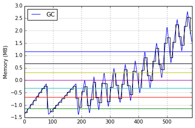

```python
import pandas as pd
import numpy as np
from scipy.stats import norm
import matplotlib.pyplot as plt
from IPython.display import display

window_size = 10
alphabet = ['a','b','c','d','e','f','g','h']
alphabet_size = len(alphabet)

# SAX Boundaries
boundaries = norm.ppf(np.linspace(1./alphabet_size,
                                  1-1./alphabet_size,
                                  alphabet_size-1))

sax_dict = dict(zip(boundaries, alphabet))

case4 = pd.read_csv('PycharmProjects/saxanalytics/case4.csv',
                    sep=',',
                    parse_dates=[0],
                    header=None,
                    names=['Time','GC'])

# z-norm the data
case4 = ((case4 - case4.mean())/case4.std())

paa = np.array_split(case4['GC'], (len(case4['GC']) / window_size) + 1)
paa = np.asarray(map(lambda xs: xs.mean(), paa))
paa_size = len(paa) - 1

ax = case4.plot()
ax.set_ylabel('Memory (MB)')

x1 = 0
x2 =  window_size

for i in xrange(0, paa_size):
    ax.plot([x1, x2], [paa[i], paa[i]], '-k')
    ax.plot([x2, x2], [paa[i], paa[i+1]], '-k')
    x1 = x1 + window_size
    x2 = x2 + window_size

for line in boundaries:
    ax.plot([0,len(case4)],[line,line])

sax_data = list()

# Convert to SAX representation
for value in paa:
    for key in sort(sax_dict.keys()):
        if value < key:
            sax_data.append(sax_dict[key])
    sax_data.append(alphabet[len(alphabet) - 1])

display(''.join(sax_data))
```

## Case 5 - Irregular GC (Not Error Condition)

###### There are cases where irregular garbage collection is simply an artifact of normal usage. This behavior is not considered an error condition as long as the memory return to normal levels. Any learning system should be able to identify this correctly as not being a problematic behavior.

```
'abcdefghbcdefghcdefghdefghefghghhhbcdefghdefghghbcdefghabcde…'
```

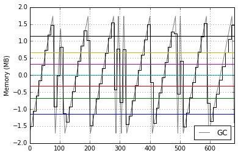

```python
import pandas as pd
import numpy as np
from scipy.stats import norm
import matplotlib.pyplot as plt
from IPython.display import display

window_size = 10
alphabet = ['a','b','c','d','e','f','g','h']
alphabet_size = len(alphabet)

# SAX Boundaries
boundaries = norm.ppf(np.linspace(1./alphabet_size,
                                  1-1./alphabet_size,
                                  alphabet_size-1))

sax_dict = dict(zip(boundaries, alphabet))

case5 = pd.read_csv('PycharmProjects/saxanalytics/case5.csv',
                    sep=',',
                    parse_dates=[0],
                    header=None,
                    names=['Time','GC'])

# z-norm the data
case5 = ((case5 - case5.mean())/case5.std())

paa = np.array_split(case5['GC'], (len(case5['GC']) / window_size) + 1)
paa = np.asarray(map(lambda xs: xs.mean(), paa))
paa_size = len(paa) - 1

ax = case5.plot(style='grey')
ax.set_ylabel('Memory (MB)')

x1 = 0
x2 =  window_size

for i in xrange(0, paa_size):
    ax.plot([x1, x2], [paa[i], paa[i]], '-k')
    ax.plot([x2, x2], [paa[i], paa[i+1]], '-k')
    x1 = x1 + window_size
    x2 = x2 + window_size

for line in boundaries:
    ax.plot([0,len(case5)],[line,line])

sax_data = list()

# Convert to SAX representation
for value in paa:
    for key in sort(sax_dict.keys()):
        if value < key:
            sax_data.append(sax_dict[key])
    sax_data.append(alphabet[len(alphabet) - 1])

display(''.join(sax_data))
```